# 1. Frequentist Inference, Interval Estimation and Hypothesis Testing

2023-05-09

> [*Back to content page*](https://flatter11.github.io/6040/)

[Lecture notes in notion](https://www.notion.so/1-Frequentist-Inference-Interval-Estimation-and-Hypothesis-Testing-382961a2a5ad4acaa535d95f56dde18e#88b43ed0321842e596e630d8357bf63c)

## 1 Log likelihood

### a) Plot

*Plot the log likelihood function as in slide 19.*

```r
# Note: theta represents the probability of success
logL <- function(theta){60*log(theta)+508*log(1-theta)} #Simplified/proportional likelihood
```

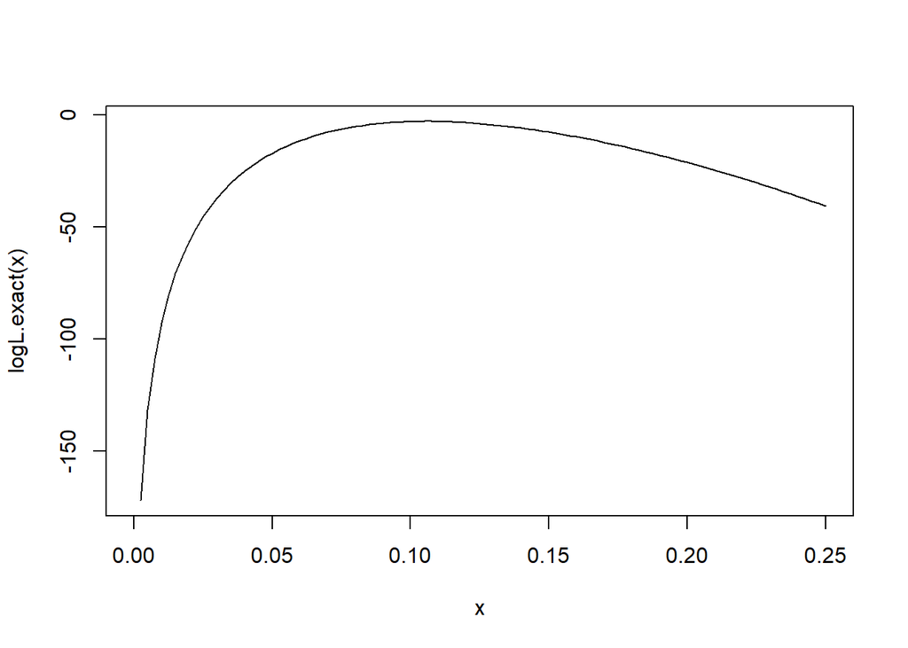

```r
logL.exact <- function(theta){dbinom(60, 568, theta, log=T)} #Exact likelihood
curve(logL.exact, from = 0, to = 0.25)
```

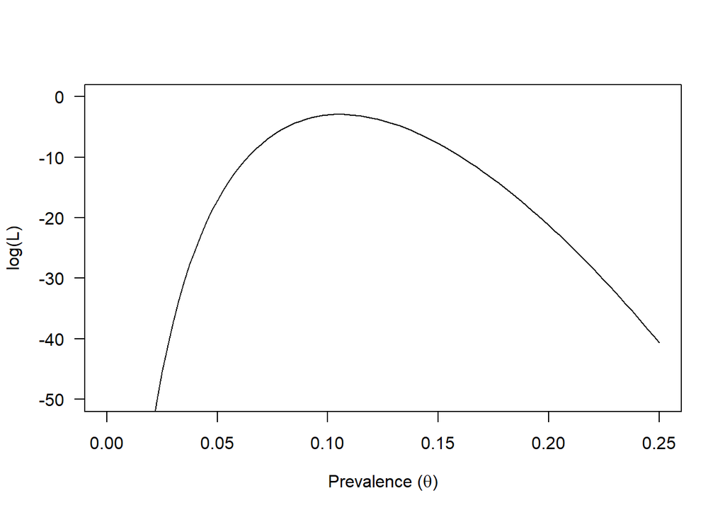

```r
# A prettier plot:
curve(logL.exact, from = 0, to = 0.25, ylim = c(-50,0), las=1,
      xlab=expression(paste('Prevalence (',theta,')')), ylab='log(L)')
```

```r
# Mathematical expressions can be included in the plot title or axis labels.
# For more information, see ?plotmath or run the demo with demo(plotmath).
# xlab can be written as expression(paste(Prevalence~(theta))
# paste() will take multiple elements as inputs and concatenate those inputs into a single string.
```

### b) Max likelihood

*Find θ so that the log likelihood is maximized.*

```r
## Use optim
optim(0.1, logL, method="CG", control=list(fnscale=-1))
optim(0.1, logL, method="Brent", lower=0.01, upper=0.25, control=list(fnscale=-1))
optim(0.1, logL, method="L-BFGS-B", lower=0.01, upper=0.99, control=list(fnscale=-1))
# alternatively, you may define a new function -logL for minimization
```

```
## $par
## [1] 0.1056346
##
## $value
## [1] -191.5797
##
## $counts
## function gradient
##       62        5
##
## $convergence
## [1] 0
##
## $message
## NULL
##
## $par
## [1] 0.1056338
##
## $value
## [1] -191.5797
##
## $counts
## function gradient
##       NA       NA
##
## $convergence
## [1] 0
##
## $message
## NULL
##
## $par
## [1] 0.1056337
##
## $value
## [1] -191.5797
##
## $counts
## function gradient
##        8        8
##
## $convergence
## [1] 0
##
## $message
## [1] "CONVERGENCE: REL_REDUCTION_OF_F <= FACTR*EPSMCH"
```

Solution keypoint

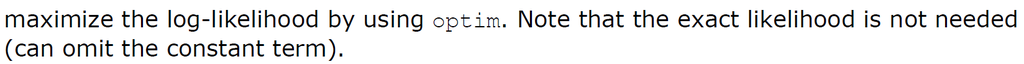

### c) Repeat a & b

*Repeat (a), (b) for the poisson likelihood on slide 21.*

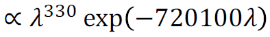

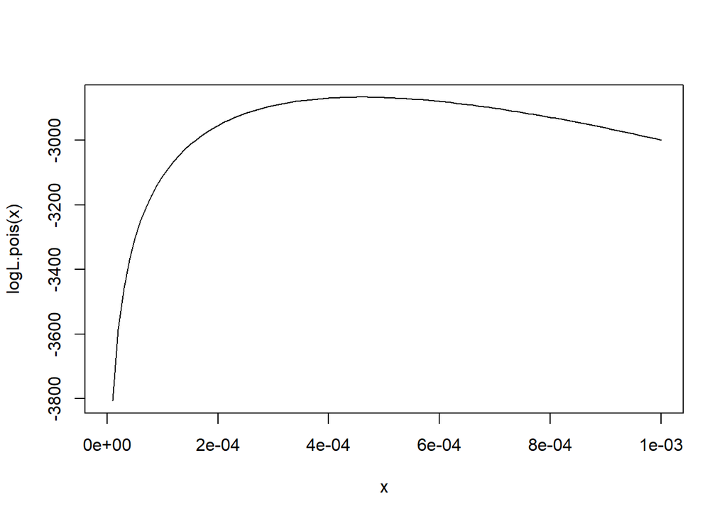

```r
## Plot
logL.pois <- function(lambda)log(lambda^330 * exp(-720100*lambda)) #why is this not working
logL.pois <- function(lambda){330*log(lambda) - 720100*lambda}
curve(logL.pois, from=0, to=0.001)
```

```r
## Max likelihood
optim(0., logL.pois, method="Brent", lower=0, upper=0.001, control=list(fnscale=-1))
```

```
## $par
## [1] 0.0004582698
##
## $value
## [1] -2867.057
##
## $counts
## function gradient
##       NA       NA
##
## $convergence
## [1] 0
##
## $message
## NULL
```

### Functions

If a specific task is desired but there is no such predefined function in R, use user-defined functions.

- `fname <- function (arg1, arg2, …) statement`
  - **arg1, arg2** are the input variables
  - **statement** is the body of the function, usually enclosed within braces {} for a grouped statement

```r
#Example
xsq <- function(x) x^2
xsq(5)
```

```
## [1] 25
```

### Optim

Minimize (or maximize) a function over the parameter space | [Youtube tutorial](https://www.youtube.com/watch?v=Qvye1wDa0kk)

- `optim(par, fn, lower, upper, method)`
  - **par** … the initial values for the parameters to be optimized over
  - **fn** … the function to be optimized
  - **lower, upper** … the lower and upper bound of the parameters to be optimized over method select the optimization algorithm
  - add **control=(list(fnscale=-1))** for maximization

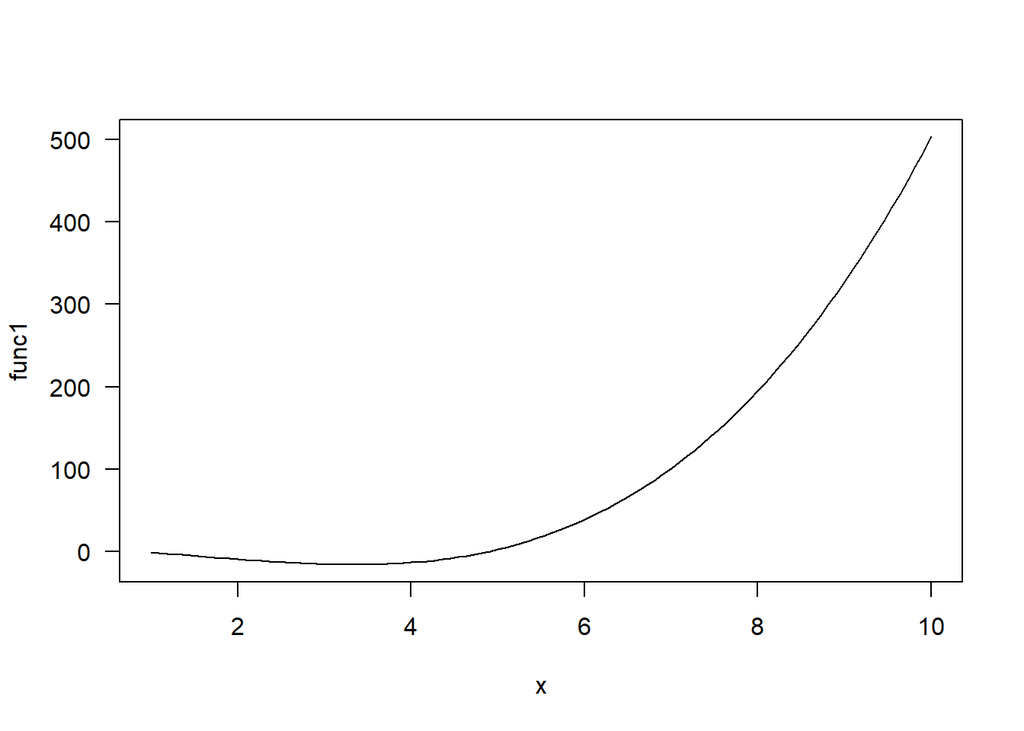

```r
# Example
func1 <- function(x) x^3 - 5*x^2 + 3
plot(func1, 1, 10, n=100, xlab="x", ylab="func1", type='l', las=1)
```

```r
optim(10, func1, lower=1, upper=10)
#Minimisation using optim: par = 3.33; value = -15.5
```

```
## $par
## [1] 3.333333
##
## $value
## [1] -15.51852
##
## $counts
## function gradient
##       11       11
##
## $convergence
## [1] 0
##
## $message
## [1] "CONVERGENCE: REL_REDUCTION_OF_F <= FACTR*EPSMCH"
```